# Лабораторная работа № 2

Настройка DNS-сервера

Баранов Никита Дмитриевич

1132242977@rudn.ru

Российский университет дружбы народов им. Патриса Лумумбы

2026-09-14

# Информация

## Докладчик

- Баранов Никита Дмитриевич
- Студент РУДН
- 1132242977@rudn.ru

# Цель и задачи

## Цель работы

- Приобрести навыки установки и конфигурирования DNS-сервера и закрепить принципы работы системы доменных имён.

## Основные этапы

# Ход работы

## Установка BIND

- На сервере установлены пакеты bind и bind-utils.

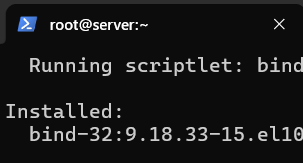

## Исходная проверка разрешения имён

- До переключения на локальный DNS выполнен запрос dig к www.yandex.ru.

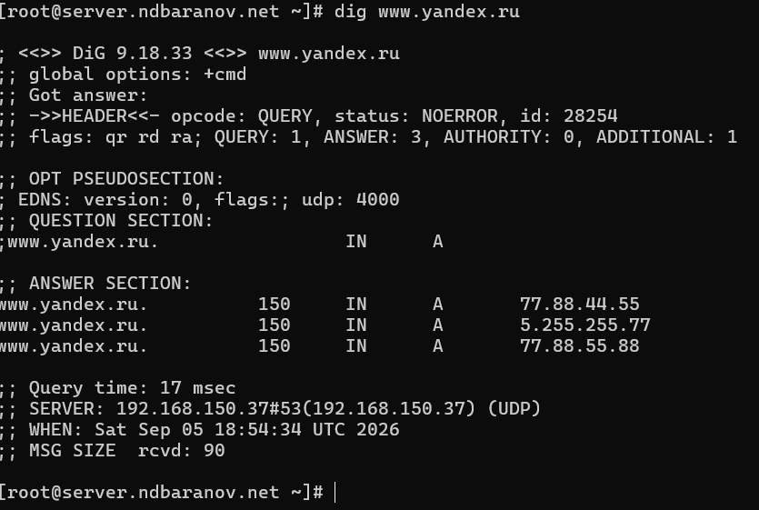

## Просмотр исходной конфигурации

- Проверены /etc/resolv.conf и стандартный /etc/named.conf.

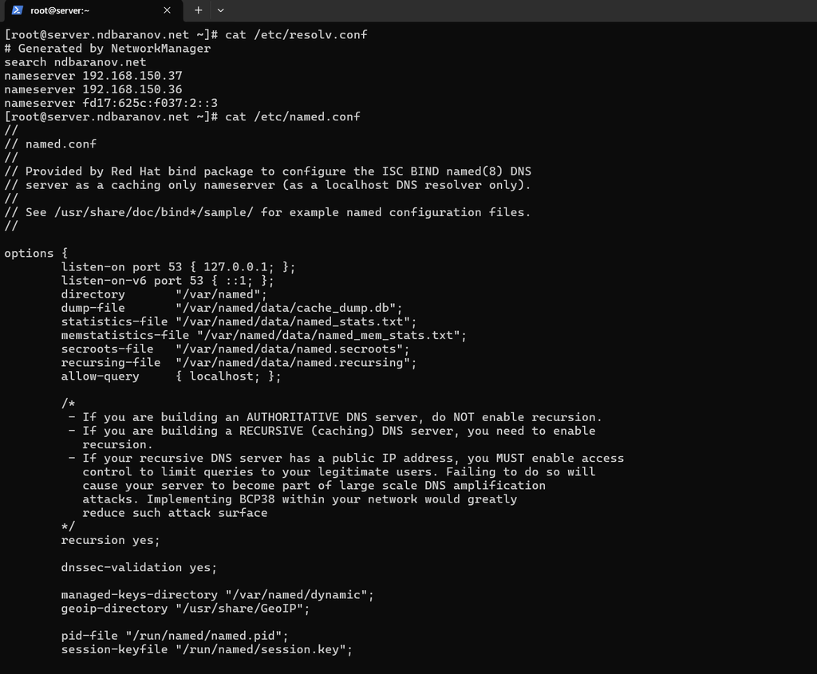

## Корневые подсказки и стандартные зоны

- Просмотрены named.ca, named.localhost и named.loopback.

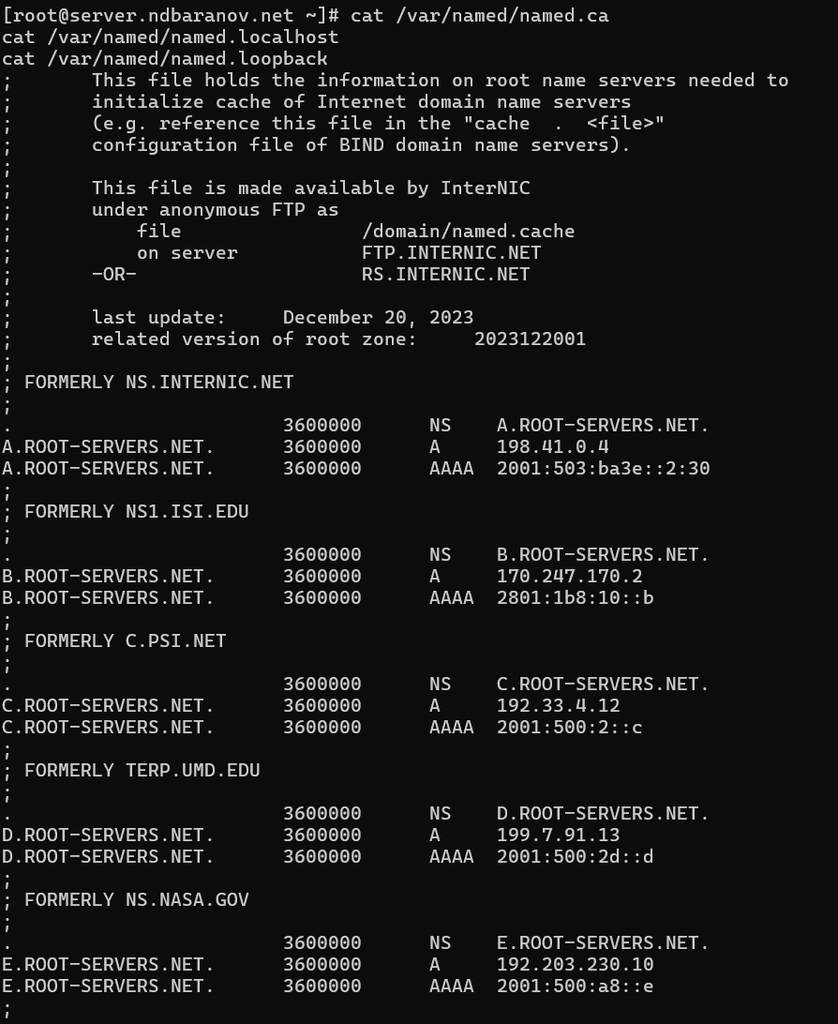

## Продолжение проверки файлов BIND

- Вывод показывает оставшуюся часть корневых подсказок и стандартных записей localhost/loopback.

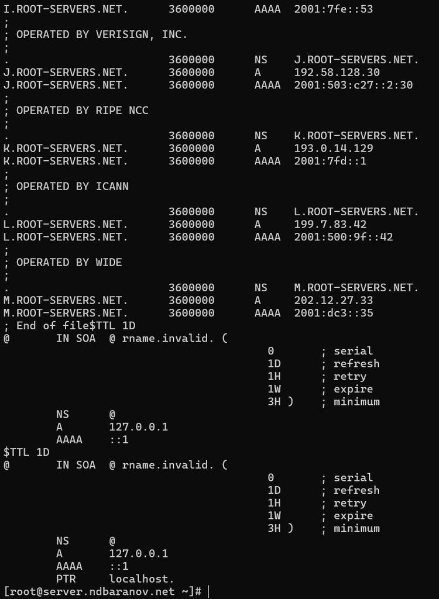

## Первый запуск локального DNS

- Служба named включена и запущена.

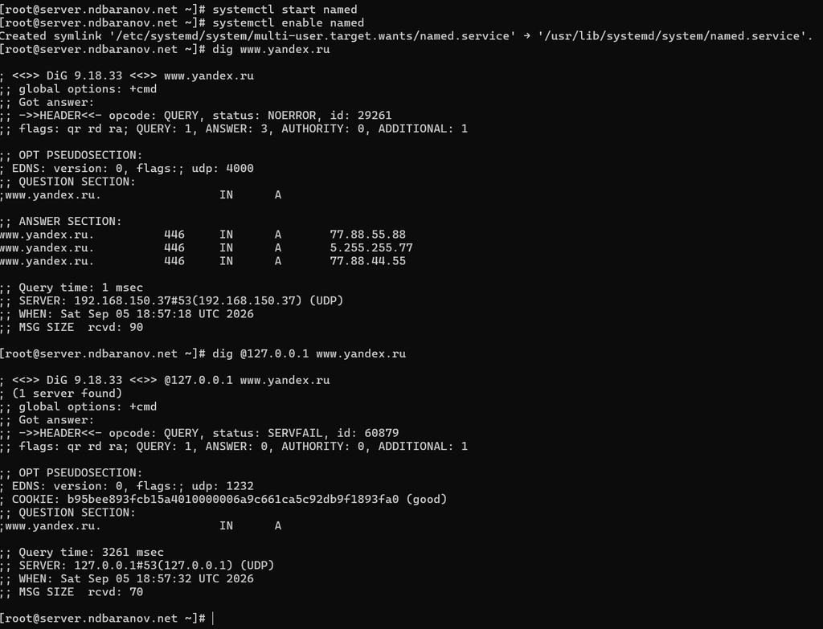

## Переключение системы на 127.0.0.1

- Через nmcli для eth0 отключено автоматическое получение DNS и задан адрес 127.0.0.1.

[figure not shown]

## Разрешение сетевых запросов в named.conf

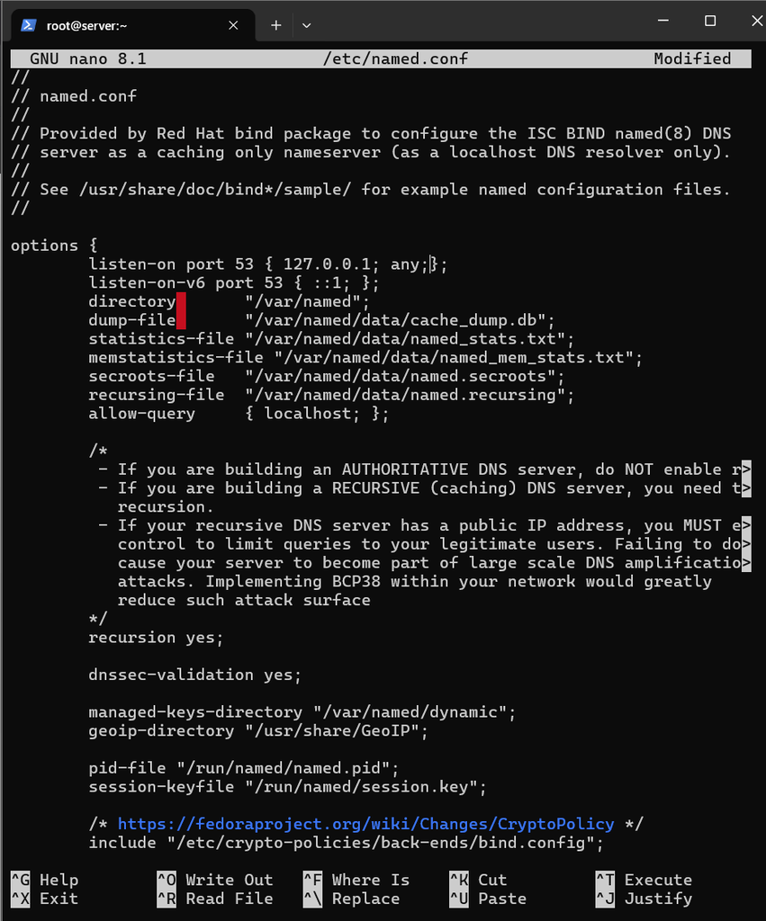

## Открытие DNS и проверка сокетов

- В firewalld разрешён сервис dns, после чего lsof показывает сокеты процесса named на порту domain.

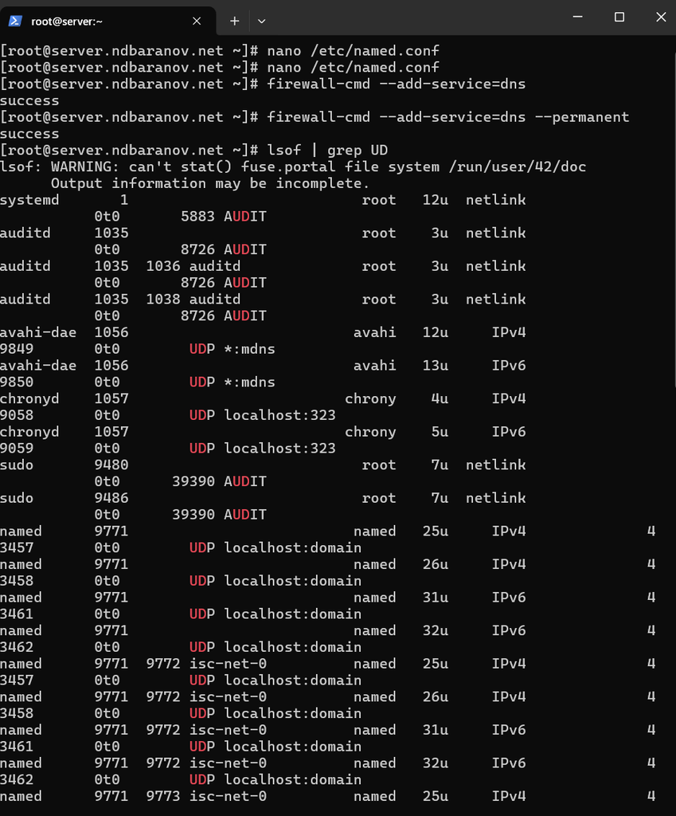

## Исправление синтаксиса и запуск named

- named-checkconf обнаружил пропущенную точку с запятой; после исправления конфигурация принята.

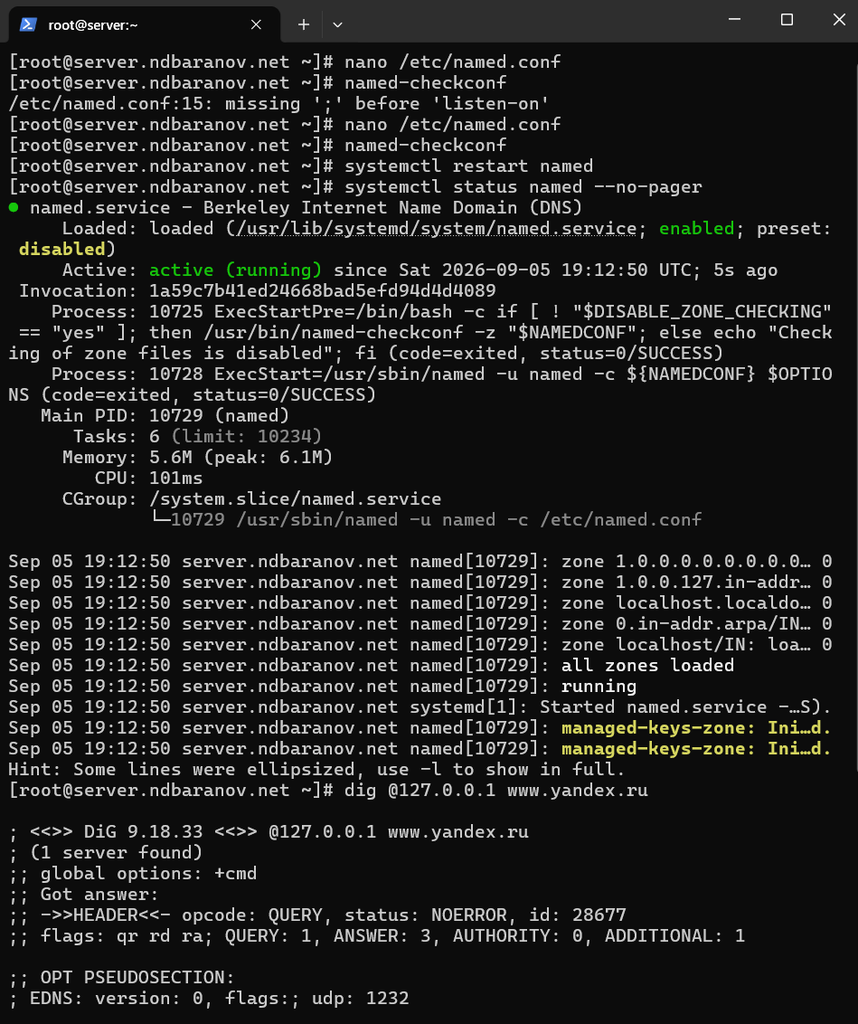

## Подготовка файлов мастер-зон

- Созданы каталоги и заготовки прямой и обратной зон, назначен владелец named, восстановлены SELinux-контексты и включён named_write_master_zones.

[figure not shown]

## Промежуточный результат NXDOMAIN

- Повторный вывод dig фиксирует NXDOMAIN от локального сервера.

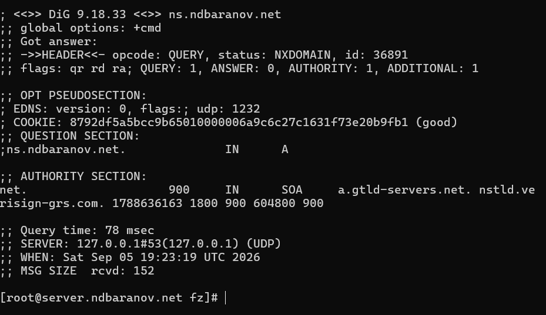

## Проверка заполненной прямой зоны

- После редактирования зоны и перезапуска named запрос dig к ns.ndbaranov.net возвращает 192.168.1.1.

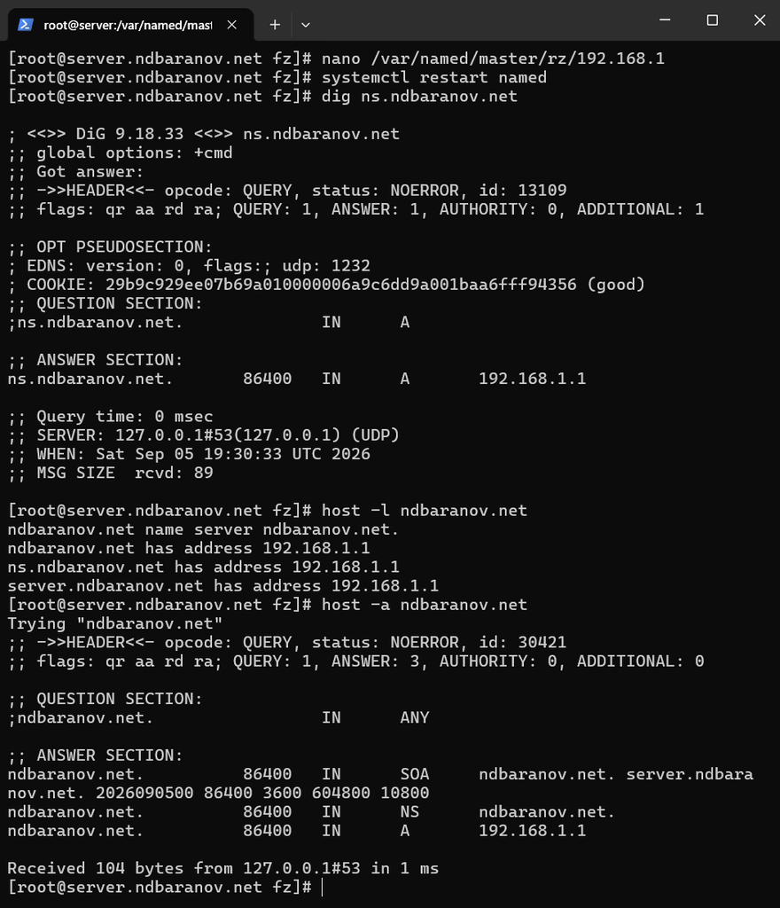

# Результаты

## Итоги работы

- Локальный BIND установлен, открыт для внутренней сети и переведён на обслуживание зоны ndbaranov.net. Итоговые dig и host подтверждают загрузку SOA, NS и A-записей.

## Спасибо за внимание